# Module 96

#### Hemi-module gene counts:

112 probesets in hemi-module A.  
25 probesets in hemi-module B.  
Note: While the mapping of probesets to genes is usually one-to-one, some genes are targeted by multiple probesets, some probesets target multiple genes, and some probesets do not target any genes (i.e., the region of the genome they match is no longer considered genic).

#### Contrast SVE:

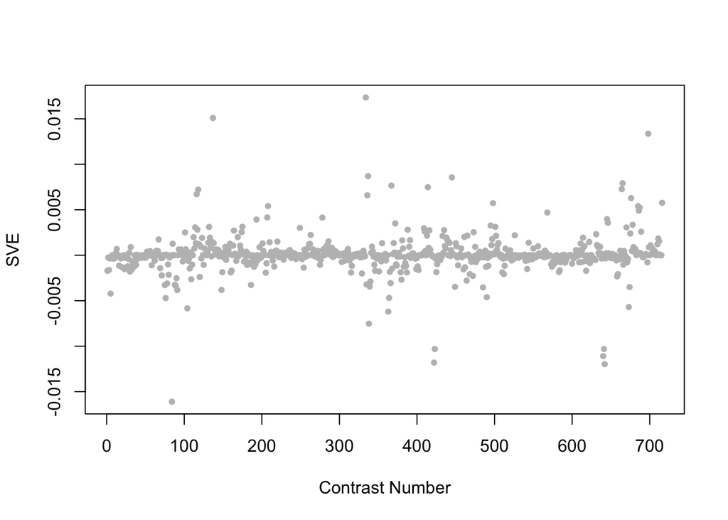

Positive SVE Contrasts:

|  | Contrast.Num | SVE | GEO.GSE | Cond.1 | Cond.2 | Mutation |
| --- | --- | --- | --- | --- | --- | --- |
| GSE38997.s4t2.vs.s1t2 | 334 | 0.02 | GSE38997 | experiment 4 UVC-exposed samples at 24 h 4u24 | experiment 4 control samples at 24 h 4c24 |  |
| GSE51691.s3t1.vs.s1t1 | 137 | 0.02 | GSE51691 | day8 hermaphrodite utx-1 RNAi -males rep 1 | day8 hermaphrodite -males rep 1 | utx-1(RNAi) |
| GSE11055.s3t4.vs.s2t4 | 698 | 0.01 | GSE11055 | L1 larvae 3 hr after hatching in the absence of food in the alternative starvation buffer M9 | L1 larvae 3 hr after hatching in the absence of food |  |
| GSE38997.s4t2.vs.s3t2 | 337 | 0.01 | GSE38997 | experiment 4 UVC-exposed samples at 24 h 4u24 | experiment 4 UVC- and EtBr-exposed samples at 24 h 4eu24 |  |
| GSE27677B.s0t9.vs.s0t7 | 445 | 0.01 | GSE27677 | N2, Fed 48 h, rep 1 | N2, Fed 24 h, rep 1 |  |

Negative SVE Contrasts:

|  | Contrast.Num | SVE | GEO.GSE | Cond.1 | Cond.2 | Mutation |
| --- | --- | --- | --- | --- | --- | --- |
| GSE6547.s2t2.vs.s0t2 | 84 | -0.02 | GSE6547 | slr-2(ku297) worms at L1 stage, first replicate | N2 (wt) worms at L1 stage, first replicate | sir-2 |
| GSE18132.s0t2.vs.s0t1 | 642 | -0.01 | GSE18132 | WT Fed L4, biological rep1 | WT Starved L1, biological rep1 |  |
| GSE28494.s1t2.vs.s1t1 | 422 | -0.01 | GSE28494 | lin-54(n3423) dissected germline 1 | lin-54(n2990) embryo 1 |  |
| GSE18132.s2t2.vs.s2t1 | 640 | -0.01 | GSE18132 | Oga Fed L4, biological replicate 1 | Oga starved L1, biological replicate 1 |  |
| GSE28494.s0t2.vs.s0t1 | 423 | -0.01 | GSE28494 | wild-type N2 dissected germline 1 | wild-type N2 embryo 1 |  |

$~$

#### Contrast SVE, Up-Regulated Genes Only:

Calculating SVE for up-regulated and down-regulated genes separately may be more informative in many cases than projecting the up- and down- gene sets together. This is due to the fact that the weight distribution of many modules is highly skewed, indicating that only one of the hemi-modules may be biologically meaningful (i.e., a set of genes are strongly correlated by only a few genes (or none) are strongly anti-correlated to that set.)

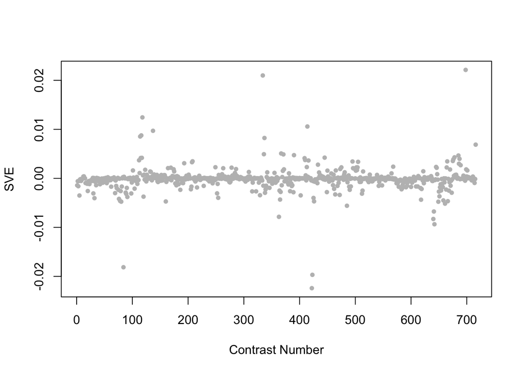

Positive SVE Contrasts:

|  | Contrast.Num | SVE | GEO.GSE | Cond.1 | Cond.2 | Mutation |
| --- | --- | --- | --- | --- | --- | --- |
| GSE11055.s3t4.vs.s2t4 | 698 | 0.02 | GSE11055 | L1 larvae 3 hr after hatching in the absence of food in the alternative starvation buffer M9 | L1 larvae 3 hr after hatching in the absence of food |  |
| GSE38997.s4t2.vs.s1t2 | 334 | 0.02 | GSE38997 | experiment 4 UVC-exposed samples at 24 h 4u24 | experiment 4 control samples at 24 h 4c24 |  |
| GSE54024.s2t1.vs.s6t1 | 118 | 0.01 | GSE54024 | Wild type young adults treated with 0.1mM paraquat, biological rep 1 | isp-1(qm150) ced-4(n1162) double mutant young adults, biological rep 1 |  |
| GSE29951.s1t1.vs.s0t1 | 414 | 0.01 | GSE29951 | C.elegans MT KO mtl-1,mtl-2(zs1), raised in the absence of Cd, rep1 | C.elegans wild type raised in the absence of Cd, rep1 | mtl-1;mtl-2 |
| GSE51691.s3t1.vs.s1t1 | 137 | 0.01 | GSE51691 | day8 hermaphrodite utx-1 RNAi -males rep 1 | day8 hermaphrodite -males rep 1 | utx-1(RNAi) |

Negative SVE Contrasts:

|  | Contrast.Num | SVE | GEO.GSE | Cond.1 | Cond.2 | Mutation |
| --- | --- | --- | --- | --- | --- | --- |
| GSE28494.s1t2.vs.s1t1 | 422 | -0.02 | GSE28494 | lin-54(n3423) dissected germline 1 | lin-54(n2990) embryo 1 |  |
| GSE28494.s0t2.vs.s0t1 | 423 | -0.02 | GSE28494 | wild-type N2 dissected germline 1 | wild-type N2 embryo 1 |  |
| GSE6547.s2t2.vs.s0t2 | 84 | -0.02 | GSE6547 | slr-2(ku297) worms at L1 stage, first replicate | N2 (wt) worms at L1 stage, first replicate | sir-2 |
| GSE18132.s0t2.vs.s0t1 | 642 | -0.01 | GSE18132 | WT Fed L4, biological rep1 | WT Starved L1, biological rep1 |  |
| GSE18132.s2t2.vs.s2t1 | 640 | -0.01 | GSE18132 | Oga Fed L4, biological replicate 1 | Oga starved L1, biological replicate 1 |  |

$~$

#### Contrast SVE, Down-Regulated Genes Only:

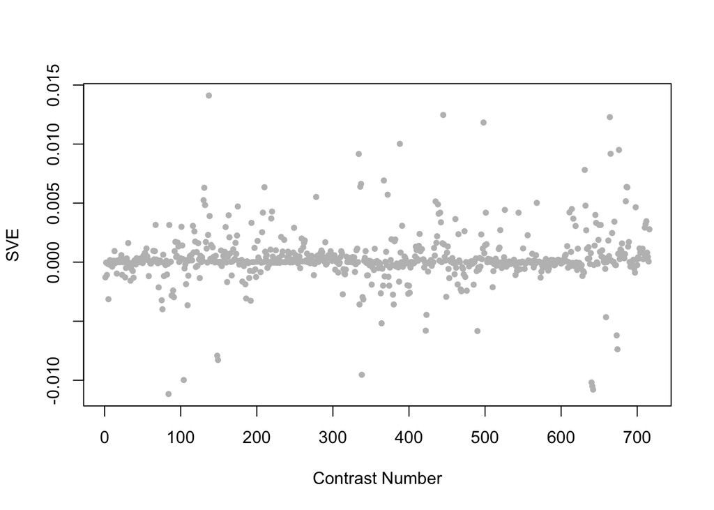

Positive SVE Contrasts:

|  | Contrast.Num | SVE | GEO.GSE | Cond.1 | Cond.2 | Mutation |
| --- | --- | --- | --- | --- | --- | --- |
| GSE51691.s3t1.vs.s1t1 | 137 | 0.01 | GSE51691 | day8 hermaphrodite utx-1 RNAi -males rep 1 | day8 hermaphrodite -males rep 1 | utx-1(RNAi) |
| GSE27677B.s0t9.vs.s0t7 | 445 | 0.01 | GSE27677 | N2, Fed 48 h, rep 1 | N2, Fed 24 h, rep 1 |  |
| GSE15159.s2t2.vs.s0t2 | 664 | 0.01 | GSE15159 | xpa-1_UV_2007_rep1 | N2_UV_2007_rep1 | xpa-1 |
| GSE23013.s4t1.vs.s0t1 | 498 | 0.01 | GSE23013 | young adult_24hr Benzene exposure_rep1 | young adult_not exposed_rep1 |  |
| GSE32949.s1t1.vs.s0t1 | 388 | 0.01 | GSE32949 | C. elegans exposed to space condition, technical rep1 | C. elegans ground control, technical rep1 |  |

Negative SVE Contrasts:

|  | Contrast.Num | SVE | GEO.GSE | Cond.1 | Cond.2 | Mutation |
| --- | --- | --- | --- | --- | --- | --- |
| GSE6547.s2t2.vs.s0t2 | 84 | -0.01 | GSE6547 | slr-2(ku297) worms at L1 stage, first replicate | N2 (wt) worms at L1 stage, first replicate | sir-2 |
| GSE18132.s0t2.vs.s0t1 | 642 | -0.01 | GSE18132 | WT Fed L4, biological rep1 | WT Starved L1, biological rep1 |  |
| GSE18132.s1t2.vs.s1t1 | 641 | -0.01 | GSE18132 | Ogt Fed L4, biological replicate 1 | Ogt starved L1, biological replicate 1 |  |
| GSE18132.s2t2.vs.s2t1 | 640 | -0.01 | GSE18132 | Oga Fed L4, biological replicate 1 | Oga starved L1, biological replicate 1 |  |
| GSE57664.s1t1.vs.s0t1 | 104 | -0.01 | GSE57664 | TYR treated rep1 | control rep1 |  |

$~$

$~$

#### GO Term Enrichment:

This analysis tests each hemi-module for enrichment of specific GO terms. Only gene-level annotations (e.g., as would be found on the gene’s page in Wormbase) are tested - the hierarchical structure of the GO ontology is not taken into account.

*Note: At least the top two most enriched terms from each GO domain (BP/MF/CC) are shown, even when not statistically significant.*

##### Enriched GO terms: Hemi-module A

| ID | GO.Term | GO Domain | Raw p-value | Adj p-value |
| --- | --- | --- | --- | --- |
| [GO_0008299](http://amigo.geneontology.org/amigo/term/GO:0008299) | isoprenoid biosynthetic process | BP | 7.89e-04 | 9.97e-01 |
| [GO_0032482](http://amigo.geneontology.org/amigo/term/GO:0032482) | Rab protein signal transduction | BP | 8.37e-04 | 9.97e-01 |
| [GO_0008301](http://amigo.geneontology.org/amigo/term/GO:0008301) | DNA binding, bending | MF | 1.15e-04 | 2.34e-01 |
| [GO_0003924](http://amigo.geneontology.org/amigo/term/GO:0003924) | GTPase activity | MF | 2.32e-04 | 2.37e-01 |
| [GO_0031985](http://amigo.geneontology.org/amigo/term/GO:0031985) | Golgi cisterna | CC | 2.28e-04 | 2.12e-01 |
| [GO_0005634](http://amigo.geneontology.org/amigo/term/GO:0005634) | nucleus | CC | 5.50e-03 | 9.64e-01 |

##### Enriched GO terms: Hemi-module B

| ID | GO.Term | GO Domain | Raw p-value | Adj p-value |
| --- | --- | --- | --- | --- |
| [GO_0032511](http://amigo.geneontology.org/amigo/term/GO:0032511) | late endosome to vacuole transport via multivesicular body sorting pathway | BP | 1.99e-03 | 1.00e+00 |
| [GO_0001508](http://amigo.geneontology.org/amigo/term/GO:0001508) | action potential | BP | 4.98e-03 | 1.00e+00 |
| [GO_0008556](http://amigo.geneontology.org/amigo/term/GO:0008556) | potassium-transporting ATPase activity | MF | 1.99e-03 | 1.00e+00 |
| [GO_0005391](http://amigo.geneontology.org/amigo/term/GO:0005391) | sodium:potassium-exchanging ATPase activity | MF | 7.95e-03 | 1.00e+00 |
| [GO_0044292](http://amigo.geneontology.org/amigo/term/GO:0044292) | dendrite terminus | CC | 5.97e-03 | 1.00e+00 |
| [GO_0035869](http://amigo.geneontology.org/amigo/term/GO:0035869) | ciliary transition zone | CC | 2.37e-02 | 1.00e+00 |

$~$

$~$

#### Tissue Enrichment:

This analysis tests each hemi-module for enrichment of genes associated with anatomy terms. Negative enrichment scores indicate fewer hemi-module genes than expected by random chance were associated with the anatomy term in question.

##### Enriched tissues: Hemi-module A

No significant annotations.

##### Enriched tissues: Hemi-module B

| ID | Anatomy.Term | Definition | Raw p-value | Adj p-value |
| --- | --- | --- | --- | --- |
| [WBbt_0006309](https://wormbase.org/species/all/anatomy_term/WBbt:0006309) | ABarapappa | embryonic cell | 8.02e-05 | 2.80e-02 |
| [WBbt_0005964](https://wormbase.org/species/all/anatomy_term/WBbt:0005964) | Cppaa | embryonic cell | 1.30e-04 | 2.80e-02 |
| [WBbt_0005973](https://wormbase.org/species/all/anatomy_term/WBbt:0005973) | ABarapaap | embryonic cell | 1.45e-04 | 2.80e-02 |
| [WBbt_0006700](https://wormbase.org/species/all/anatomy_term/WBbt:0006700) | Cppap | embryonic cell | 1.45e-04 | 2.80e-02 |
| [WBbt_0006181](https://wormbase.org/species/all/anatomy_term/WBbt:0006181) | ABalpaapa | embryonic cell | 1.60e-04 | 2.80e-02 |
| [WBbt_0005913](https://wormbase.org/species/all/anatomy_term/WBbt:0005913) | MSppaap | embryonic cell | 1.76e-04 | 2.80e-02 |
| [WBbt_0006668](https://wormbase.org/species/all/anatomy_term/WBbt:0006668) | Capaa | embryonic cell | 1.76e-04 | 2.80e-02 |
| [WBbt_0005860](https://wormbase.org/species/all/anatomy_term/WBbt:0005860) | ABarapaaa | embryonic cell | 1.93e-04 | 2.80e-02 |
| [WBbt_0006307](https://wormbase.org/species/all/anatomy_term/WBbt:0006307) | Capap | embryonic cell | 1.93e-04 | 2.80e-02 |
| [WBbt_0006135](https://wormbase.org/species/all/anatomy_term/WBbt:0006135) | ABaraaaaa | embryonic cell | 2.10e-04 | 2.80e-02 |
| [WBbt_0006185](https://wormbase.org/species/all/anatomy_term/WBbt:0006185) | Cappp | embryonic cell | 2.28e-04 | 2.80e-02 |
| [WBbt_0006400](https://wormbase.org/species/all/anatomy_term/WBbt:0006400) | ABalpppaa | embryonic cell | 2.28e-04 | 2.80e-02 |
| [WBbt_0006024](https://wormbase.org/species/all/anatomy_term/WBbt:0006024) | Cpppa | embryonic cell | 2.47e-04 | 2.80e-02 |
| [WBbt_0006311](https://wormbase.org/species/all/anatomy_term/WBbt:0006311) | ABaraaaap | embryonic cell | 2.47e-04 | 2.80e-02 |
| [WBbt_0006664](https://wormbase.org/species/all/anatomy_term/WBbt:0006664) | Cappa | embryonic cell | 2.47e-04 | 2.80e-02 |
| [WBbt_0006708](https://wormbase.org/species/all/anatomy_term/WBbt:0006708) | ABalpaapp | embryonic cell | 2.47e-04 | 2.80e-02 |
| [WBbt_0005846](https://wormbase.org/species/all/anatomy_term/WBbt:0005846) | ABalppapa | embryonic cell | 2.67e-04 | 2.80e-02 |
| [WBbt_0006300](https://wormbase.org/species/all/anatomy_term/WBbt:0006300) | ABarppppa | embryonic cell | 3.08e-04 | 2.80e-02 |
| [WBbt_0006356](https://wormbase.org/species/all/anatomy_term/WBbt:0006356) | ABplppapp | embryonic cell | 3.08e-04 | 2.80e-02 |
| [WBbt_0006631](https://wormbase.org/species/all/anatomy_term/WBbt:0006631) | ABpraaaaa | embryonic cell | 3.08e-04 | 2.80e-02 |
| [WBbt_0005895](https://wormbase.org/species/all/anatomy_term/WBbt:0005895) | ABpraaapa | embryonic cell | 3.30e-04 | 2.80e-02 |
| [WBbt_0005961](https://wormbase.org/species/all/anatomy_term/WBbt:0005961) | ABprapaaa | embryonic cell | 3.30e-04 | 2.80e-02 |
| [WBbt_0006055](https://wormbase.org/species/all/anatomy_term/WBbt:0006055) | ABprppppa | embryonic cell | 3.30e-04 | 2.80e-02 |
| [WBbt_0005955](https://wormbase.org/species/all/anatomy_term/WBbt:0005955) | ABplpapaa | embryonic cell | 3.53e-04 | 2.80e-02 |
| [WBbt_0006186](https://wormbase.org/species/all/anatomy_term/WBbt:0006186) | ABarppppp | embryonic cell | 3.53e-04 | 2.80e-02 |
| [WBbt_0006189](https://wormbase.org/species/all/anatomy_term/WBbt:0006189) | ABaraaapp | embryonic cell | 3.53e-04 | 2.80e-02 |
| [WBbt_0006222](https://wormbase.org/species/all/anatomy_term/WBbt:0006222) | ABplpppaa | embryonic cell | 3.53e-04 | 2.80e-02 |
| [WBbt_0006352](https://wormbase.org/species/all/anatomy_term/WBbt:0006352) | ABplppppa | embryonic cell | 3.76e-04 | 2.80e-02 |
| [WBbt_0005983](https://wormbase.org/species/all/anatomy_term/WBbt:0005983) | ABprppppp | embryonic cell | 4.00e-04 | 2.80e-02 |
| [WBbt_0006041](https://wormbase.org/species/all/anatomy_term/WBbt:0006041) | ABarpppaa | embryonic cell | 4.00e-04 | 2.80e-02 |
| [WBbt_0006062](https://wormbase.org/species/all/anatomy_term/WBbt:0006062) | ABpraapap | embryonic cell | 4.00e-04 | 2.80e-02 |
| [WBbt_0006290](https://wormbase.org/species/all/anatomy_term/WBbt:0006290) | ABprapapp | embryonic cell | 4.00e-04 | 2.80e-02 |
| [WBbt_0006624](https://wormbase.org/species/all/anatomy_term/WBbt:0006624) | ABprapaap | embryonic cell | 4.00e-04 | 2.80e-02 |
| [WBbt_0005948](https://wormbase.org/species/all/anatomy_term/WBbt:0005948) | ABplaappp | embryonic cell | 4.25e-04 | 2.80e-02 |
| [WBbt_0006237](https://wormbase.org/species/all/anatomy_term/WBbt:0006237) | ABprpppap | embryonic cell | 4.25e-04 | 2.80e-02 |
| [WBbt_0006251](https://wormbase.org/species/all/anatomy_term/WBbt:0006251) | ABarpppap | embryonic cell | 4.25e-04 | 2.80e-02 |
| [WBbt_0006665](https://wormbase.org/species/all/anatomy_term/WBbt:0006665) | ABplpppap | embryonic cell | 4.25e-04 | 2.80e-02 |
| [WBbt_0006108](https://wormbase.org/species/all/anatomy_term/WBbt:0006108) | ABpraapaa | embryonic cell | 4.77e-04 | 2.88e-02 |
| [WBbt_0006232](https://wormbase.org/species/all/anatomy_term/WBbt:0006232) | ABplpappa | embryonic cell | 4.77e-04 | 2.88e-02 |
| [WBbt_0006446](https://wormbase.org/species/all/anatomy_term/WBbt:0006446) | ABprpapaa | embryonic cell | 4.77e-04 | 2.88e-02 |
| [WBbt_0006123](https://wormbase.org/species/all/anatomy_term/WBbt:0006123) | Caapa | embryonic cell | 5.04e-04 | 2.88e-02 |
| [WBbt_0006088](https://wormbase.org/species/all/anatomy_term/WBbt:0006088) | ABprpappa | embryonic cell | 5.32e-04 | 2.88e-02 |
| [WBbt_0006390](https://wormbase.org/species/all/anatomy_term/WBbt:0006390) | ABplpappp | embryonic cell | 5.32e-04 | 2.88e-02 |
| [WBbt_0006519](https://wormbase.org/species/all/anatomy_term/WBbt:0006519) | ABplaappa | embryonic cell | 5.32e-04 | 2.88e-02 |
| [WBbt_0006552](https://wormbase.org/species/all/anatomy_term/WBbt:0006552) | ABprpppaa | embryonic cell | 5.32e-04 | 2.88e-02 |
| [WBbt_0006270](https://wormbase.org/species/all/anatomy_term/WBbt:0006270) | ABpraappp | embryonic cell | 5.61e-04 | 2.90e-02 |
| [WBbt_0006594](https://wormbase.org/species/all/anatomy_term/WBbt:0006594) | Cpaap | embryonic cell | 5.61e-04 | 2.90e-02 |
| [WBbt_0006212](https://wormbase.org/species/all/anatomy_term/WBbt:0006212) | Cpaaa | embryonic cell | 5.90e-04 | 2.99e-02 |
| [WBbt_0006035](https://wormbase.org/species/all/anatomy_term/WBbt:0006035) | ABpraappa | embryonic cell | 6.51e-04 | 3.23e-02 |
| [WBbt_0006267](https://wormbase.org/species/all/anatomy_term/WBbt:0006267) | Caaap | embryonic cell | 6.82e-04 | 3.32e-02 |
| [WBbt_0006398](https://wormbase.org/species/all/anatomy_term/WBbt:0006398) | ABarpaaa | embryonic cell | 7.14e-04 | 3.41e-02 |
| [WBbt_0005962](https://wormbase.org/species/all/anatomy_term/WBbt:0005962) | Cpapa | embryonic cell | 7.47e-04 | 3.50e-02 |
| [WBbt_0005897](https://wormbase.org/species/all/anatomy_term/WBbt:0005897) | Cpapp | embryonic cell | 7.81e-04 | 3.58e-02 |

$~$

$~$

#### HOMER promoter motif enrichment:

This analysis tests each hemi-module for enrichment of 108 known *C. elegans* transcription factor binding site motifs (see [108 CE motifs](https://katiepod.github.io//all.worm.motifs.html)) using the HOMER (Hypergeometric Optimization of Motif EnRichment) software (see [PMID:20513432](https://pubmed.ncbi.nlm.nih.gov/20513432)). HOMER was run using default parameters on sequences 1 kb upstream of the transcription start site.

##### Motif enrichment: Hemi-module A

Total target sequences = 102  
Total background sequences = 37932  
* - possible false positive

Rank

Motif

P-value

log P-pvalue

% of Targets

% of Background

STD(Bg STD)

Best Match/Details

Motif File

1 *

[figure not shown]

1e-9

-2.148e+01

8.82%

0.39%

229.3bp (290.2bp)

skn-1/MA0547.1/Jaspar(0.610)  
[More Information](https://katiepod.github.io/HomerResults/m96_a_hemi_genes.txt.out.1kb/homerResults/motif1.info.html) | [Similar Motifs Found](https://katiepod.github.io/HomerResults/m96_a_hemi_genes.txt.out.1kb/homerResults/motif1.similar.html)

[motif file (matrix)](https://katiepod.github.io/HomerResults/m96_a_hemi_genes.txt.out.1kb/homerResults/motif1.motif)

2 *

[figure not shown]

1e-9

-2.117e+01

7.84%

0.27%

196.7bp (334.9bp)

lin-54/MA1450.1/Jaspar(0.643)  
[More Information](https://katiepod.github.io/HomerResults/m96_a_hemi_genes.txt.out.1kb/homerResults/motif2.info.html) | [Similar Motifs Found](https://katiepod.github.io/HomerResults/m96_a_hemi_genes.txt.out.1kb/homerResults/motif2.similar.html)

[motif file (matrix)](https://katiepod.github.io/HomerResults/m96_a_hemi_genes.txt.out.1kb/homerResults/motif2.motif)

3 *

[figure not shown]

1e-8

-2.025e+01

13.73%

1.63%

278.6bp (330.6bp)

PL0003.1_hlh-2::cnd-1/Jaspar(0.572)  
[More Information](https://katiepod.github.io/HomerResults/m96_a_hemi_genes.txt.out.1kb/homerResults/motif3.info.html) | [Similar Motifs Found](https://katiepod.github.io/HomerResults/m96_a_hemi_genes.txt.out.1kb/homerResults/motif3.similar.html)

[motif file (matrix)](https://katiepod.github.io/HomerResults/m96_a_hemi_genes.txt.out.1kb/homerResults/motif3.motif)

4 *

[figure not shown]

1e-8

-1.943e+01

11.76%

1.17%

185.5bp (316.4bp)

che-1/MA0260.1/Jaspar(0.634)  
[More Information](https://katiepod.github.io/HomerResults/m96_a_hemi_genes.txt.out.1kb/homerResults/motif4.info.html) | [Similar Motifs Found](https://katiepod.github.io/HomerResults/m96_a_hemi_genes.txt.out.1kb/homerResults/motif4.similar.html)

[motif file (matrix)](https://katiepod.github.io/HomerResults/m96_a_hemi_genes.txt.out.1kb/homerResults/motif4.motif)

5 *

[figure not shown]

1e-8

-1.891e+01

19.61%

4.09%

334.1bp (322.2bp)

blmp-1/MA0537.1/Jaspar(0.649)  
[More Information](https://katiepod.github.io/HomerResults/m96_a_hemi_genes.txt.out.1kb/homerResults/motif5.info.html) | [Similar Motifs Found](https://katiepod.github.io/HomerResults/m96_a_hemi_genes.txt.out.1kb/homerResults/motif5.similar.html)

[motif file (matrix)](https://katiepod.github.io/HomerResults/m96_a_hemi_genes.txt.out.1kb/homerResults/motif5.motif)

6 *

[figure not shown]

1e-8

-1.886e+01

7.84%

0.37%

250.8bp (319.4bp)

POL011.1_XCPE1/Jaspar(0.688)  
[More Information](https://katiepod.github.io/HomerResults/m96_a_hemi_genes.txt.out.1kb/homerResults/motif6.info.html) | [Similar Motifs Found](https://katiepod.github.io/HomerResults/m96_a_hemi_genes.txt.out.1kb/homerResults/motif6.similar.html)

[motif file (matrix)](https://katiepod.github.io/HomerResults/m96_a_hemi_genes.txt.out.1kb/homerResults/motif6.motif)

7 *

[figure not shown]

1e-8

-1.883e+01

6.86%

0.23%

237.1bp (353.8bp)

daf-16/MA1446.1/Jaspar(0.627)  
[More Information](https://katiepod.github.io/HomerResults/m96_a_hemi_genes.txt.out.1kb/homerResults/motif7.info.html) | [Similar Motifs Found](https://katiepod.github.io/HomerResults/m96_a_hemi_genes.txt.out.1kb/homerResults/motif7.similar.html)

[motif file (matrix)](https://katiepod.github.io/HomerResults/m96_a_hemi_genes.txt.out.1kb/homerResults/motif7.motif)

8 *

[figure not shown]

1e-7

-1.834e+01

27.45%

8.27%

283.1bp (327.2bp)

daf-12/MA0538.1/Jaspar(0.810)  
[More Information](https://katiepod.github.io/HomerResults/m96_a_hemi_genes.txt.out.1kb/homerResults/motif8.info.html) | [Similar Motifs Found](https://katiepod.github.io/HomerResults/m96_a_hemi_genes.txt.out.1kb/homerResults/motif8.similar.html)

[motif file (matrix)](https://katiepod.github.io/HomerResults/m96_a_hemi_genes.txt.out.1kb/homerResults/motif8.motif)

9 *

[figure not shown]

1e-7

-1.750e+01

12.75%

1.70%

292.2bp (351.1bp)

lin-54/MA1450.1/Jaspar(0.600)  
[More Information](https://katiepod.github.io/HomerResults/m96_a_hemi_genes.txt.out.1kb/homerResults/motif9.info.html) | [Similar Motifs Found](https://katiepod.github.io/HomerResults/m96_a_hemi_genes.txt.out.1kb/homerResults/motif9.similar.html)

[motif file (matrix)](https://katiepod.github.io/HomerResults/m96_a_hemi_genes.txt.out.1kb/homerResults/motif9.motif)

10 *

[figure not shown]

1e-7

-1.730e+01

14.71%

2.43%

313.4bp (294.1bp)

POL012.1_TATA-Box/Jaspar(0.713)  
[More Information](https://katiepod.github.io/HomerResults/m96_a_hemi_genes.txt.out.1kb/homerResults/motif10.info.html) | [Similar Motifs Found](https://katiepod.github.io/HomerResults/m96_a_hemi_genes.txt.out.1kb/homerResults/motif10.similar.html)

[motif file (matrix)](https://katiepod.github.io/HomerResults/m96_a_hemi_genes.txt.out.1kb/homerResults/motif10.motif)

11 *

[figure not shown]

1e-7

-1.728e+01

7.84%

0.45%

214.9bp (298.1bp)

nhr-6/MA1451.1/Jaspar(0.599)  
[More Information](https://katiepod.github.io/HomerResults/m96_a_hemi_genes.txt.out.1kb/homerResults/motif11.info.html) | [Similar Motifs Found](https://katiepod.github.io/HomerResults/m96_a_hemi_genes.txt.out.1kb/homerResults/motif11.similar.html)

[motif file (matrix)](https://katiepod.github.io/HomerResults/m96_a_hemi_genes.txt.out.1kb/homerResults/motif11.motif)

12 *

[figure not shown]

1e-7

-1.620e+01

8.82%

0.74%

238.6bp (348.0bp)

hlh-30/MA1449.1/Jaspar(0.630)  
[More Information](https://katiepod.github.io/HomerResults/m96_a_hemi_genes.txt.out.1kb/homerResults/motif12.info.html) | [Similar Motifs Found](https://katiepod.github.io/HomerResults/m96_a_hemi_genes.txt.out.1kb/homerResults/motif12.similar.html)

[motif file (matrix)](https://katiepod.github.io/HomerResults/m96_a_hemi_genes.txt.out.1kb/homerResults/motif12.motif)

13 *

[figure not shown]

1e-6

-1.580e+01

7.84%

0.55%

294.7bp (310.3bp)

efl-1/MA0541.1/Jaspar(0.646)  
[More Information](https://katiepod.github.io/HomerResults/m96_a_hemi_genes.txt.out.1kb/homerResults/motif13.info.html) | [Similar Motifs Found](https://katiepod.github.io/HomerResults/m96_a_hemi_genes.txt.out.1kb/homerResults/motif13.similar.html)

[motif file (matrix)](https://katiepod.github.io/HomerResults/m96_a_hemi_genes.txt.out.1kb/homerResults/motif13.motif)

14 *

[figure not shown]

1e-6

-1.473e+01

47.06%

24.11%

294.4bp (349.8bp)

POL006.1_BREu/Jaspar(0.780)  
[More Information](https://katiepod.github.io/HomerResults/m96_a_hemi_genes.txt.out.1kb/homerResults/motif14.info.html) | [Similar Motifs Found](https://katiepod.github.io/HomerResults/m96_a_hemi_genes.txt.out.1kb/homerResults/motif14.similar.html)

[motif file (matrix)](https://katiepod.github.io/HomerResults/m96_a_hemi_genes.txt.out.1kb/homerResults/motif14.motif)

15 *

[figure not shown]

1e-6

-1.473e+01

7.84%

0.64%

344.2bp (263.8bp)

MF0011.1_HMG_class/Jaspar(0.674)  
[More Information](https://katiepod.github.io/HomerResults/m96_a_hemi_genes.txt.out.1kb/homerResults/motif15.info.html) | [Similar Motifs Found](https://katiepod.github.io/HomerResults/m96_a_hemi_genes.txt.out.1kb/homerResults/motif15.similar.html)

[motif file (matrix)](https://katiepod.github.io/HomerResults/m96_a_hemi_genes.txt.out.1kb/homerResults/motif15.motif)

16 *

[figure not shown]

1e-6

-1.462e+01

9.80%

1.18%

276.8bp (344.8bp)

fos-1/MA1448.1/Jaspar(0.580)  
[More Information](https://katiepod.github.io/HomerResults/m96_a_hemi_genes.txt.out.1kb/homerResults/motif16.info.html) | [Similar Motifs Found](https://katiepod.github.io/HomerResults/m96_a_hemi_genes.txt.out.1kb/homerResults/motif16.similar.html)

[motif file (matrix)](https://katiepod.github.io/HomerResults/m96_a_hemi_genes.txt.out.1kb/homerResults/motif16.motif)

17 *

[figure not shown]

1e-5

-1.337e+01

17.65%

4.75%

208.2bp (365.3bp)

cebp-1/MA1444.1/Jaspar(0.672)  
[More Information](https://katiepod.github.io/HomerResults/m96_a_hemi_genes.txt.out.1kb/homerResults/motif17.info.html) | [Similar Motifs Found](https://katiepod.github.io/HomerResults/m96_a_hemi_genes.txt.out.1kb/homerResults/motif17.similar.html)

[motif file (matrix)](https://katiepod.github.io/HomerResults/m96_a_hemi_genes.txt.out.1kb/homerResults/motif17.motif)

18 *

[figure not shown]

1e-5

-1.271e+01

4.90%

0.21%

217.5bp (321.1bp)

che-1/MA0260.1/Jaspar(0.574)  
[More Information](https://katiepod.github.io/HomerResults/m96_a_hemi_genes.txt.out.1kb/homerResults/motif18.info.html) | [Similar Motifs Found](https://katiepod.github.io/HomerResults/m96_a_hemi_genes.txt.out.1kb/homerResults/motif18.similar.html)

[motif file (matrix)](https://katiepod.github.io/HomerResults/m96_a_hemi_genes.txt.out.1kb/homerResults/motif18.motif)

19 *

[figure not shown]

1e-5

-1.269e+01

27.45%

10.89%

276.8bp (363.9bp)

ceh-28/MA1445.1/Jaspar(0.687)  
[More Information](https://katiepod.github.io/HomerResults/m96_a_hemi_genes.txt.out.1kb/homerResults/motif19.info.html) | [Similar Motifs Found](https://katiepod.github.io/HomerResults/m96_a_hemi_genes.txt.out.1kb/homerResults/motif19.similar.html)

[motif file (matrix)](https://katiepod.github.io/HomerResults/m96_a_hemi_genes.txt.out.1kb/homerResults/motif19.motif)

20 *

[figure not shown]

1e-5

-1.217e+01

28.43%

11.86%

303.0bp (308.7bp)

pal-1/MA0924.1/Jaspar(0.643)  
[More Information](https://katiepod.github.io/HomerResults/m96_a_hemi_genes.txt.out.1kb/homerResults/motif20.info.html) | [Similar Motifs Found](https://katiepod.github.io/HomerResults/m96_a_hemi_genes.txt.out.1kb/homerResults/motif20.similar.html)

[motif file (matrix)](https://katiepod.github.io/HomerResults/m96_a_hemi_genes.txt.out.1kb/homerResults/motif20.motif)

21 *

[figure not shown]

1e-4

-1.006e+01

12.75%

3.37%

209.1bp (352.8bp)

PL0018.1_hlh-25/Jaspar(0.568)  
[More Information](https://katiepod.github.io/HomerResults/m96_a_hemi_genes.txt.out.1kb/homerResults/motif21.info.html) | [Similar Motifs Found](https://katiepod.github.io/HomerResults/m96_a_hemi_genes.txt.out.1kb/homerResults/motif21.similar.html)

[motif file (matrix)](https://katiepod.github.io/HomerResults/m96_a_hemi_genes.txt.out.1kb/homerResults/motif21.motif)

22 *

[figure not shown]

1e-4

-9.824e+00

15.69%

5.04%

312.0bp (313.7bp)

dpy-27/MA0540.1/Jaspar(0.514)  
[More Information](https://katiepod.github.io/HomerResults/m96_a_hemi_genes.txt.out.1kb/homerResults/motif22.info.html) | [Similar Motifs Found](https://katiepod.github.io/HomerResults/m96_a_hemi_genes.txt.out.1kb/homerResults/motif22.similar.html)

[motif file (matrix)](https://katiepod.github.io/HomerResults/m96_a_hemi_genes.txt.out.1kb/homerResults/motif22.motif)

23 *

[figure not shown]

1e-4

-9.604e+00

5.88%

0.66%

244.5bp (316.0bp)

MF0010.1_Homeobox_class/Jaspar(0.587)  
[More Information](https://katiepod.github.io/HomerResults/m96_a_hemi_genes.txt.out.1kb/homerResults/motif23.info.html) | [Similar Motifs Found](https://katiepod.github.io/HomerResults/m96_a_hemi_genes.txt.out.1kb/homerResults/motif23.similar.html)

[motif file (matrix)](https://katiepod.github.io/HomerResults/m96_a_hemi_genes.txt.out.1kb/homerResults/motif23.motif)

24 *

[figure not shown]

1e-4

-9.598e+00

12.75%

3.53%

281.5bp (338.3bp)

eor-1/MA0543.1/Jaspar(0.641)  
[More Information](https://katiepod.github.io/HomerResults/m96_a_hemi_genes.txt.out.1kb/homerResults/motif24.info.html) | [Similar Motifs Found](https://katiepod.github.io/HomerResults/m96_a_hemi_genes.txt.out.1kb/homerResults/motif24.similar.html)

[motif file (matrix)](https://katiepod.github.io/HomerResults/m96_a_hemi_genes.txt.out.1kb/homerResults/motif24.motif)

25 *

[figure not shown]

1e-4

-9.562e+00

1.96%

0.01%

173.4bp (245.7bp)

eor-1/MA0543.1/Jaspar(0.562)  
[More Information](https://katiepod.github.io/HomerResults/m96_a_hemi_genes.txt.out.1kb/homerResults/motif25.info.html) | [Similar Motifs Found](https://katiepod.github.io/HomerResults/m96_a_hemi_genes.txt.out.1kb/homerResults/motif25.similar.html)

[motif file (matrix)](https://katiepod.github.io/HomerResults/m96_a_hemi_genes.txt.out.1kb/homerResults/motif25.motif)

26 *

[figure not shown]

1e-4

-9.414e+00

5.88%

0.68%

257.1bp (301.9bp)

pha-4/MA0546.1/Jaspar(0.683)  
[More Information](https://katiepod.github.io/HomerResults/m96_a_hemi_genes.txt.out.1kb/homerResults/motif26.info.html) | [Similar Motifs Found](https://katiepod.github.io/HomerResults/m96_a_hemi_genes.txt.out.1kb/homerResults/motif26.similar.html)

[motif file (matrix)](https://katiepod.github.io/HomerResults/m96_a_hemi_genes.txt.out.1kb/homerResults/motif26.motif)

27 *

[figure not shown]

1e-3

-8.469e+00

17.65%

6.90%

320.7bp (307.7bp)

PHA-4(Forkhead)/cElegans-Embryos-PHA4-ChIP-Seq(modEncode)/Homer(0.583)  
[More Information](https://katiepod.github.io/HomerResults/m96_a_hemi_genes.txt.out.1kb/homerResults/motif27.info.html) | [Similar Motifs Found](https://katiepod.github.io/HomerResults/m96_a_hemi_genes.txt.out.1kb/homerResults/motif27.similar.html)

[motif file (matrix)](https://katiepod.github.io/HomerResults/m96_a_hemi_genes.txt.out.1kb/homerResults/motif27.motif)

28 *

[figure not shown]

1e-3

-7.184e+00

3.92%

0.39%

231.1bp (367.8bp)

POL007.1_BREd/Jaspar(0.550)  
[More Information](https://katiepod.github.io/HomerResults/m96_a_hemi_genes.txt.out.1kb/homerResults/motif28.info.html) | [Similar Motifs Found](https://katiepod.github.io/HomerResults/m96_a_hemi_genes.txt.out.1kb/homerResults/motif28.similar.html)

[motif file (matrix)](https://katiepod.github.io/HomerResults/m96_a_hemi_genes.txt.out.1kb/homerResults/motif28.motif)

29 *

[figure not shown]

1e-2

-6.710e+00

2.94%

0.20%

222.4bp (303.3bp)

POL013.1_MED-1/Jaspar(0.507)  
[More Information](https://katiepod.github.io/HomerResults/m96_a_hemi_genes.txt.out.1kb/homerResults/motif29.info.html) | [Similar Motifs Found](https://katiepod.github.io/HomerResults/m96_a_hemi_genes.txt.out.1kb/homerResults/motif29.similar.html)

[motif file (matrix)](https://katiepod.github.io/HomerResults/m96_a_hemi_genes.txt.out.1kb/homerResults/motif29.motif)

30 *

[figure not shown]

1e-2

-5.642e+00

3.92%

0.60%

238.1bp (377.5bp)

POL004.1_CCAAT-box/Jaspar(0.518)  
[More Information](https://katiepod.github.io/HomerResults/m96_a_hemi_genes.txt.out.1kb/homerResults/motif30.info.html) | [Similar Motifs Found](https://katiepod.github.io/HomerResults/m96_a_hemi_genes.txt.out.1kb/homerResults/motif30.similar.html)

[motif file (matrix)](https://katiepod.github.io/HomerResults/m96_a_hemi_genes.txt.out.1kb/homerResults/motif30.motif)

##### Motif enrichment: Hemi-module B

Total target sequences = 21  
Total background sequences = 31519  
* - possible false positive

Rank

Motif

P-value

log P-pvalue

% of Targets

% of Background

STD(Bg STD)

Best Match/Details

Motif File

1 *

[figure not shown]

1e-9

-2.128e+01

52.38%

4.70%

293.4bp (297.3bp)

POL008.1_DCE_S_I/Jaspar(0.571)  
[More Information](https://katiepod.github.io/HomerResults/m96_b_hemi_genes.txt.out.1kb/homerResults/motif1.info.html) | [Similar Motifs Found](https://katiepod.github.io/HomerResults/m96_b_hemi_genes.txt.out.1kb/homerResults/motif1.similar.html)

[motif file (matrix)](https://katiepod.github.io/HomerResults/m96_b_hemi_genes.txt.out.1kb/homerResults/motif1.motif)

2 *

[figure not shown]

1e-9

-2.108e+01

28.57%

0.48%

150.7bp (293.3bp)

ceh-48/MA0921.1/Jaspar(0.565)  
[More Information](https://katiepod.github.io/HomerResults/m96_b_hemi_genes.txt.out.1kb/homerResults/motif2.info.html) | [Similar Motifs Found](https://katiepod.github.io/HomerResults/m96_b_hemi_genes.txt.out.1kb/homerResults/motif2.similar.html)

[motif file (matrix)](https://katiepod.github.io/HomerResults/m96_b_hemi_genes.txt.out.1kb/homerResults/motif2.motif)

3 *

[figure not shown]

1e-7

-1.829e+01

23.81%

0.35%

247.2bp (332.0bp)

POL010.1_DCE_S_III/Jaspar(0.580)  
[More Information](https://katiepod.github.io/HomerResults/m96_b_hemi_genes.txt.out.1kb/homerResults/motif3.info.html) | [Similar Motifs Found](https://katiepod.github.io/HomerResults/m96_b_hemi_genes.txt.out.1kb/homerResults/motif3.similar.html)

[motif file (matrix)](https://katiepod.github.io/HomerResults/m96_b_hemi_genes.txt.out.1kb/homerResults/motif3.motif)

4 *

[figure not shown]

1e-7

-1.807e+01

14.29%

0.02%

193.9bp (267.5bp)

PL0008.1_hlh-29/Jaspar(0.536)  
[More Information](https://katiepod.github.io/HomerResults/m96_b_hemi_genes.txt.out.1kb/homerResults/motif4.info.html) | [Similar Motifs Found](https://katiepod.github.io/HomerResults/m96_b_hemi_genes.txt.out.1kb/homerResults/motif4.similar.html)

[motif file (matrix)](https://katiepod.github.io/HomerResults/m96_b_hemi_genes.txt.out.1kb/homerResults/motif4.motif)

5 *

[figure not shown]

1e-4

-1.103e+01

19.05%

0.73%

376.9bp (317.7bp)

MF0010.1_Homeobox_class/Jaspar(0.618)  
[More Information](https://katiepod.github.io/HomerResults/m96_b_hemi_genes.txt.out.1kb/homerResults/motif5.info.html) | [Similar Motifs Found](https://katiepod.github.io/HomerResults/m96_b_hemi_genes.txt.out.1kb/homerResults/motif5.similar.html)

[motif file (matrix)](https://katiepod.github.io/HomerResults/m96_b_hemi_genes.txt.out.1kb/homerResults/motif5.motif)

6 *

[figure not shown]

1e-4

-1.098e+01

57.14%

15.77%

273.7bp (297.7bp)

lim-7/MA1441.1/Jaspar(0.720)  
[More Information](https://katiepod.github.io/HomerResults/m96_b_hemi_genes.txt.out.1kb/homerResults/motif6.info.html) | [Similar Motifs Found](https://katiepod.github.io/HomerResults/m96_b_hemi_genes.txt.out.1kb/homerResults/motif6.similar.html)

[motif file (matrix)](https://katiepod.github.io/HomerResults/m96_b_hemi_genes.txt.out.1kb/homerResults/motif6.motif)

7 *

[figure not shown]

1e-4

-9.370e+00

57.14%

18.42%

220.3bp (300.3bp)

POL013.1_MED-1/Jaspar(0.543)  
[More Information](https://katiepod.github.io/HomerResults/m96_b_hemi_genes.txt.out.1kb/homerResults/motif7.info.html) | [Similar Motifs Found](https://katiepod.github.io/HomerResults/m96_b_hemi_genes.txt.out.1kb/homerResults/motif7.similar.html)

[motif file (matrix)](https://katiepod.github.io/HomerResults/m96_b_hemi_genes.txt.out.1kb/homerResults/motif7.motif)

8 *

[figure not shown]

1e-3

-8.704e+00

28.57%

4.16%

296.9bp (301.3bp)

PL0009.1_hlh-26/Jaspar(0.525)  
[More Information](https://katiepod.github.io/HomerResults/m96_b_hemi_genes.txt.out.1kb/homerResults/motif8.info.html) | [Similar Motifs Found](https://katiepod.github.io/HomerResults/m96_b_hemi_genes.txt.out.1kb/homerResults/motif8.similar.html)

[motif file (matrix)](https://katiepod.github.io/HomerResults/m96_b_hemi_genes.txt.out.1kb/homerResults/motif8.motif)

9 *

[figure not shown]

1e-3

-8.478e+00

38.10%

8.53%

286.8bp (313.0bp)

PL0017.1_hlh-2::hlh-10/Jaspar(0.591)  
[More Information](https://katiepod.github.io/HomerResults/m96_b_hemi_genes.txt.out.1kb/homerResults/motif9.info.html) | [Similar Motifs Found](https://katiepod.github.io/HomerResults/m96_b_hemi_genes.txt.out.1kb/homerResults/motif9.similar.html)

[motif file (matrix)](https://katiepod.github.io/HomerResults/m96_b_hemi_genes.txt.out.1kb/homerResults/motif9.motif)

10 *

[figure not shown]

1e-3

-8.355e+00

38.10%

8.68%

282.4bp (301.2bp)

EGL-5(Homeobox)/cElegans-L3-EGL5-ChIP-Seq(modEncode)/Homer(0.573)  
[More Information](https://katiepod.github.io/HomerResults/m96_b_hemi_genes.txt.out.1kb/homerResults/motif10.info.html) | [Similar Motifs Found](https://katiepod.github.io/HomerResults/m96_b_hemi_genes.txt.out.1kb/homerResults/motif10.similar.html)

[motif file (matrix)](https://katiepod.github.io/HomerResults/m96_b_hemi_genes.txt.out.1kb/homerResults/motif10.motif)

11 *

[figure not shown]

1e-3

-8.127e+00

28.57%

4.63%

272.5bp (321.2bp)

unc-62/MA0918.1/Jaspar(0.546)  
[More Information](https://katiepod.github.io/HomerResults/m96_b_hemi_genes.txt.out.1kb/homerResults/motif11.info.html) | [Similar Motifs Found](https://katiepod.github.io/HomerResults/m96_b_hemi_genes.txt.out.1kb/homerResults/motif11.similar.html)

[motif file (matrix)](https://katiepod.github.io/HomerResults/m96_b_hemi_genes.txt.out.1kb/homerResults/motif11.motif)

12 *

[figure not shown]

1e-3

-7.947e+00

14.29%

0.66%

181.1bp (305.5bp)

MF0008.1_MADS_class/Jaspar(0.594)  
[More Information](https://katiepod.github.io/HomerResults/m96_b_hemi_genes.txt.out.1kb/homerResults/motif12.info.html) | [Similar Motifs Found](https://katiepod.github.io/HomerResults/m96_b_hemi_genes.txt.out.1kb/homerResults/motif12.similar.html)

[motif file (matrix)](https://katiepod.github.io/HomerResults/m96_b_hemi_genes.txt.out.1kb/homerResults/motif12.motif)

13 *

[figure not shown]

1e-3

-7.487e+00

28.57%

5.22%

331.1bp (284.6bp)

ceh-38/MA1699.1/Jaspar(0.703)  
[More Information](https://katiepod.github.io/HomerResults/m96_b_hemi_genes.txt.out.1kb/homerResults/motif13.info.html) | [Similar Motifs Found](https://katiepod.github.io/HomerResults/m96_b_hemi_genes.txt.out.1kb/homerResults/motif13.similar.html)

[motif file (matrix)](https://katiepod.github.io/HomerResults/m96_b_hemi_genes.txt.out.1kb/homerResults/motif13.motif)

14 *

[figure not shown]

1e-3

-7.211e+00

66.67%

30.70%

241.4bp (311.8bp)

PL0002.1_hlh-2::hlh-3/Jaspar(0.672)  
[More Information](https://katiepod.github.io/HomerResults/m96_b_hemi_genes.txt.out.1kb/homerResults/motif14.info.html) | [Similar Motifs Found](https://katiepod.github.io/HomerResults/m96_b_hemi_genes.txt.out.1kb/homerResults/motif14.similar.html)

[motif file (matrix)](https://katiepod.github.io/HomerResults/m96_b_hemi_genes.txt.out.1kb/homerResults/motif14.motif)

15 *

[figure not shown]

1e-3

-7.192e+00

47.62%

16.14%

259.0bp (300.4bp)

MF0006.1_bZIP_cEBP-like_subclass/Jaspar(0.627)  
[More Information](https://katiepod.github.io/HomerResults/m96_b_hemi_genes.txt.out.1kb/homerResults/motif15.info.html) | [Similar Motifs Found](https://katiepod.github.io/HomerResults/m96_b_hemi_genes.txt.out.1kb/homerResults/motif15.similar.html)

[motif file (matrix)](https://katiepod.github.io/HomerResults/m96_b_hemi_genes.txt.out.1kb/homerResults/motif15.motif)

$~$

$~$

#### Promoter Word Enrichment:

This analysis tests each hemi-module for enrichment of specific promoter words. The list of promoter words tested was generated by running the MobyDick algorithm (see [PMID:10944202](https://pubmed.ncbi.nlm.nih.gov/10944202)) on the full set of *C. elegans* 2 Kbp promoters.

##### Enriched promoter words: Hemi-module A

No significant words.

##### Enriched promoter words: Hemi-module B

No significant words.

$~$

$~$

#### Promoter Word Depletion:

This analysis tests each hemi-module for depletion (under-enrichment) of specific promoter words. The list of promoter words tested was generated by running the MobyDick algorithm (see [PMID:10944202](https://pubmed.ncbi.nlm.nih.gov/10944202)) on the full set of *C. elegans* 2 Kbp promoters.

##### Depleted promoter words: Hemi-module A

No significant words.

##### Depleted promoter words: Hemi-module B

No significant words.

$~$

$~$

#### 3’-UTR Word Enrichment:

This analysis tests each hemi-module for enrichment of specific 3’-UTR words. The list of words tested was generated by running the MobyDick algorithm (see [PMID:10944202](https://pubmed.ncbi.nlm.nih.gov/10944202)) on the full set of *C. elegans* 3’-UTR sequences.

##### 3’-UTR words: Hemi-module A

No significant words.

##### 3’-UTR words: Hemi-module B

No significant words.

$~$

$~$

#### Hemi-module A genes

| affy_c_elegans | ensembl_gene_id | external_gene_name | module_weight | chromosome_name | strand | start_position | end_position |
| --- | --- | --- | --- | --- | --- | --- | --- |
| 171978_x_at | WBGene00022369 | Y92H12BR.3 | 6.20 | I | 1 | 1416586 | 1425201 |
| 194144_s_at | WBGene00004270 | rab-6.2 | 6.16 | X | 1 | 17222475 | 17224464 |
| 188091_at | WBGene00001682 | gpc-2 | 6.16 | I | 1 | 6757763 | 6758178 |
| 176148_at | WBGene00017321 | F09G8.7 | 5.67 | III | -1 | 8267921 | 8268355 |
| 177685_s_at | WBGene00009661 | patr-1 | 5.58 | II | -1 | 11774669 | 11777943 |
| 177685_s_at | WBGene00009688 | F44E5.1 | 5.58 | II | -1 | 11774144 | 11774559 |
| 186826_at | WBGene00013735 | Y111B2A.12 | 5.55 | III | 1 | 12609289 | 12623740 |
| 182055_at | WBGene00012576 | Y37H9A.1 | 5.36 | I | 1 | 13773067 | 13778782 |
| 184879_at | WBGene00020510 | T14G11.1 | 5.34 | X | 1 | 2688945 | 2692022 |
| 190294_at | WBGene00009354 | ilkp-1 | 5.33 | II | 1 | 11050260 | 11058102 |
| 176497_s_at | WBGene00021847 | Y54F10AL.1 | 5.33 | III | 1 | 2487769 | 2494340 |
| 174946_at | WBGene00004357 | rho-1 | 5.28 | IV | -1 | 16482784 | 16489021 |
| 183281_at | WBGene00016796 | cec-2 | 5.18 | IV | 1 | 1170672 | 1177776 |
| 183281_at | WBGene00022426 | Y104H12D.2 | 5.18 | IV | 1 | 1178022 | 1182837 |
| 182303_at | WBGene00017909 | F28H1.4 | 5.11 | I | -1 | 3974063 | 3977351 |
| 176087_at | WBGene00002986 | lig-4 | 5.06 | III | 1 | 7521004 | 7524836 |
| 176087_at | WBGene00015579 | C07H6.2 | 5.06 | III | 1 | 7521004 | 7521438 |
| 191648_at | WBGene00017982 | hpo-18 | 5.05 | V | -1 | 4346089 | 4346425 |
| 177280_at | WBGene00021847 | Y54F10AL.1 | 5.05 | III | 1 | 2487769 | 2494340 |
| 187844_at | WBGene00016657 | C44E12.1 | 5.00 | X | 1 | 7596927 | 7599824 |
| 181782_at | WBGene00017257 | F08F1.3 | 4.98 | X | 1 | 8428842 | 8430520 |
| 178854_at | WBGene00010870 | let-522 | 4.86 | I | -1 | 7172463 | 7174156 |
| 179523_at | WBGene00010305 | F59A2.5 | 4.79 | III | 1 | 3404863 | 3405469 |
| 183458_at | WBGene00019057 | F58F9.3 | 4.73 | IV | 1 | 6233246 | 6235666 |
| 182286_at | WBGene00018465 | F45E1.4 | 4.66 | X | 1 | 7985979 | 7988981 |
| 180675_at | WBGene00018518 | F46H5.2 | 4.65 | X | 1 | 7265652 | 7267893 |
| 175999_at | WBGene00019680 | K12H4.5 | 4.63 | III | 1 | 8044481 | 8044916 |
| 176286_at | WBGene00022083 | Y69A2AR.12 | 4.55 | IV | 1 | 2568614 | 2572056 |
| 179366_at | WBGene00009050 | F22D6.2 | 4.53 | I | -1 | 7079868 | 7081520 |
| 188308_s_at | WBGene00018417 | F44E2.3 | 4.52 | III | -1 | 8827358 | 8829305 |

[output cut: 84 more lines]

#### Hemi-module B genes

| affy_c_elegans | ensembl_gene_id | external_gene_name | module_weight | chromosome_name | strand | start_position | end_position |
| --- | --- | --- | --- | --- | --- | --- | --- |
| 181459_at | WBGene00009914 | F49H6.13 | -4.94 | V | -1 | 17008673 | 17009388 |
| 177851_at | WBGene00012176 | W01C9.2 | -4.92 | II | 1 | 8536133 | 8538603 |
| 171876_at | WBGene00010279 | letm-1 | -4.58 | V | 1 | 13661261 | 13664233 |
| 180808_at | WBGene00012313 | W06G6.11 | -4.30 | V | -1 | 16649031 | 16649300 |
| 183442_at | WBGene00010746 | K10D11.2 | -4.24 | IV | 1 | 12979017 | 12981940 |
| 191596_s_at | WBGene00020985 | W03D8.2 | -4.22 | I | -1 | 2798175 | 2800878 |
| 178434_at | WBGene00195165 | F57G4.11 | -4.18 | V | 1 | 17625127 | 17627598 |
| 177816_at | WBGene00009907 | F49H6.3 | -4.06 | V | 1 | 17014408 | 17015326 |
| 172999_s_at | WBGene00077771 | C41G7.9 | -4.06 | I | -1 | 9515002 | 9516776 |
| 173281_s_at | WBGene00004622 | rrn-3.1 | -3.90 | I | 1 | 15064838 | 15068346 |
| 173281_s_at | WBGene00004677 | rrn-3.56 | -3.90 | I | 1 | 15060299 | 15061150 |
| 177241_at | WBGene00021841 | Y54E10BR.2 | -3.85 | I | 1 | 3032935 | 3034761 |
| 174207_s_at | WBGene00007720 | C25D7.10 | -3.76 | V | 1 | 15067465 | 15068581 |
| 179867_at | WBGene00013545 | Y75B8A.8 | -3.75 | III | 1 | 12160758 | 12171356 |
| 171767_x_at | WBGene00004622 | rrn-3.1 | -3.73 | I | 1 | 15064838 | 15068346 |
| 171767_x_at | WBGene00004677 | rrn-3.56 | -3.73 | I | 1 | 15060299 | 15061150 |
| 174197_s_at | WBGene00009086 | F23D12.2 | -3.72 | X | -1 | 14416121 | 14421579 |
| 182113_at | WBGene00021076 | W07E6.5 | -3.72 | II | 1 | 476222 | 478063 |